# Data Analysis in Software Engineering

This is the R Markdown document for the talk to be given at the UCL-Software System Engineering (SSE) Reading Group (RG) on Wednesday, 12th of August, 2015. This document requires the R system and the Rstudio installed. This document executes all chunks of R code and generates an html document.

The purpose of the talk is to give a hands-on experience of what to analyse software engineering data is like. We use basic statistical procedures for analysing some public software engineering datasets.

## Outline of the talk

- The process of analysing data in software engineering
- Getting data
- Exploratory Data Analysis
- Model Building for Prediction
- Linear Regression
- Machine Learning Techniques
- Model Evaluation
- Descriptive statistics
- Confidence Intervals
- Hypothesis Testing
- p-values
- Equivalence hypothesis testing
- Frequentism vs Bayesianism

## Read a data file and explore its descriptive statistics

- Displaying information graphically will help us to identify the main characteristics of the data
- Basic Plots: Histogram, Boxplot, Q-Q plot

## Software Engineering Data is less “friendly”. Telecom1

```r
path2files <- "~/DocProjects/PRESI2013/london2015"
setwd(path2files)
telecom1 <- read.table("Telecom1.csv", sep=",",header=TRUE, stringsAsFactors=FALSE, dec = ".") #read data
summary(telecom1)
```

```
##       size            effort           EstTotal
##  Min.   :  3.00   Min.   :  23.54   Min.   : 30.0
##  1st Qu.: 37.25   1st Qu.: 119.18   1st Qu.:141.8
##  Median : 68.50   Median : 222.03   Median :289.0
##  Mean   :100.33   Mean   : 284.28   Mean   :320.3
##  3rd Qu.:164.00   3rd Qu.: 352.27   3rd Qu.:471.5
##  Max.   :284.00   Max.   :1115.54   Max.   :777.0
```

```r
par(mfrow=c(1,2))
size <- log(telecom1[1])
actual_effort <- telecom1[2]
summary(size)
```

```
##       size
##  Min.   :1.099
##  1st Qu.:3.618
##  Median :4.201
##  Mean   :3.994
##  3rd Qu.:5.083
##  Max.   :5.649
```

```r
summary(actual_effort)
```

```
##      effort
##  Min.   :  23.54
##  1st Qu.: 119.18
##  Median : 222.03
##  Mean   : 284.28
##  3rd Qu.: 352.27
##  Max.   :1115.54
```

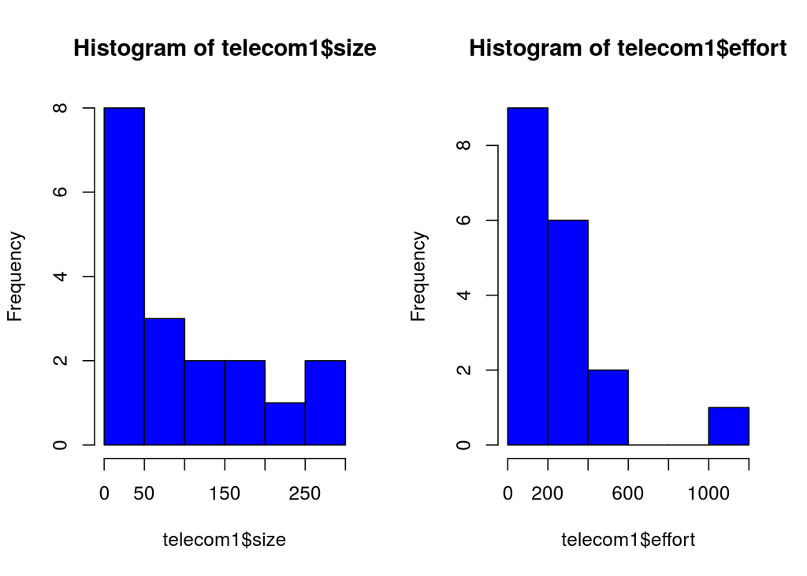

```r
hist(telecom1$size, col="blue")
hist(telecom1$effort, col="blue")
```

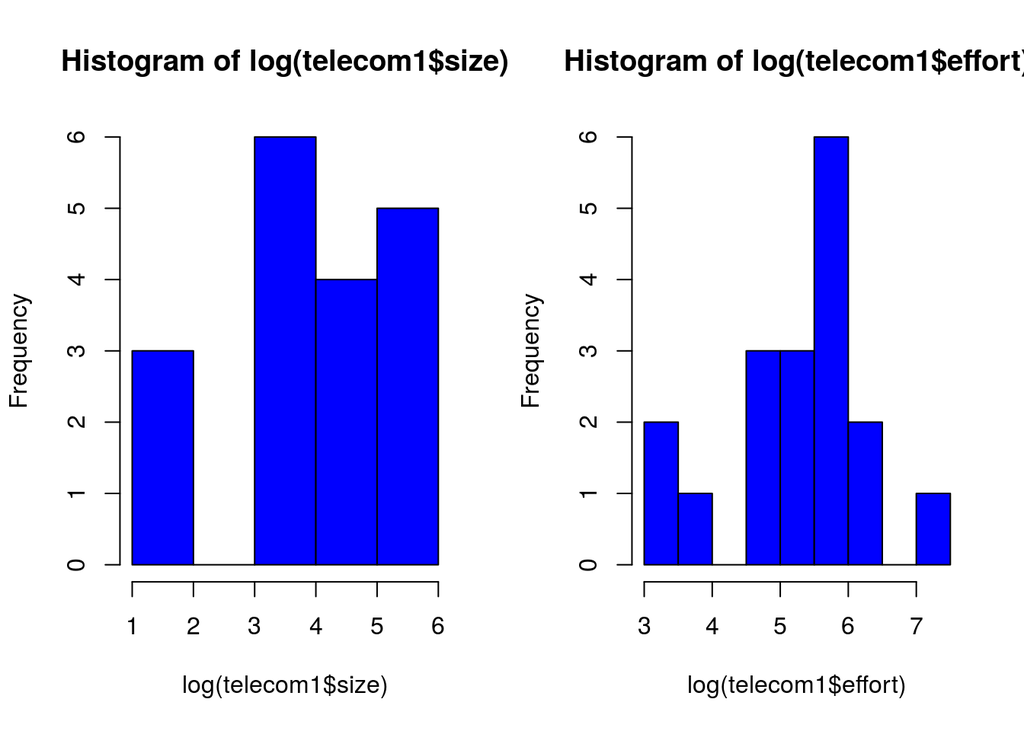

```r
hist(log(telecom1$size), col="blue")
hist(log(telecom1$effort), col="blue")
```

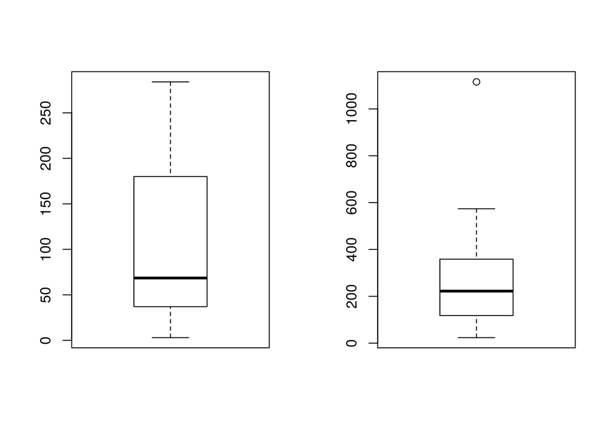

```r
boxplot(telecom1$size)
boxplot(telecom1$effort)
```

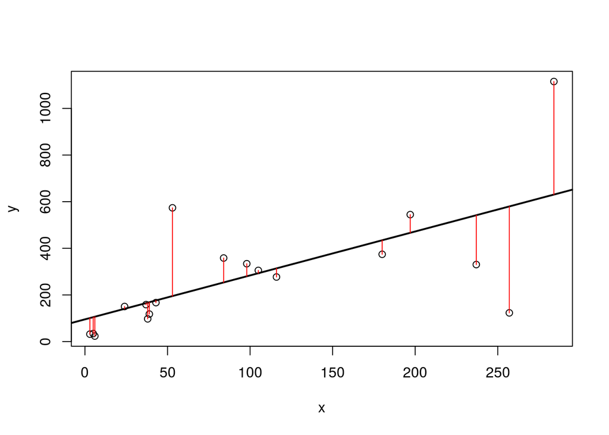

```r
par(mfrow=c(1,1))
x <- telecom1$size
y <- telecom1$effort
lmtelecom1 <- lm( y ~ x)
plot(x,y)
abline(lmtelecom1, lwd=2)

# calculate residuals and predicted values
res <- signif(residuals(lmtelecom1), 5)
pre <- predict(lmtelecom1)
# plot distances between points and the regression line
segments(x, y, x, pre, col="red")
```

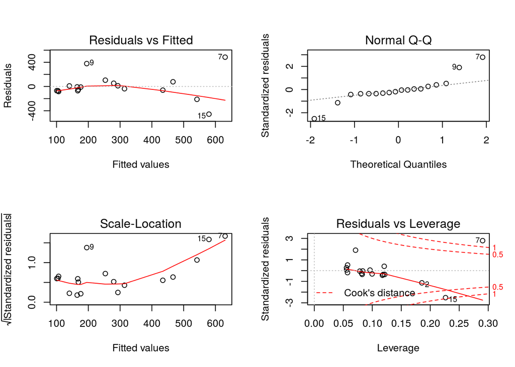

```r
par(mfrow=c(2,2))
plot(lmtelecom1)
```

## China dataset

```r
library(foreign)
china <- read.arff("china.arff")
afpsize <- china$AFP
summary(afpsize)
```

```
##    Min. 1st Qu.  Median    Mean 3rd Qu.    Max.
##     9.0   100.5   215.0   486.9   437.5 17520.0
```

```r
effort_china <- china$Effort
summary(effort_china)
```

```
##    Min. 1st Qu.  Median    Mean 3rd Qu.    Max.
##    26.0   703.5  1829.0  3921.0  3826.0 54620.0
```

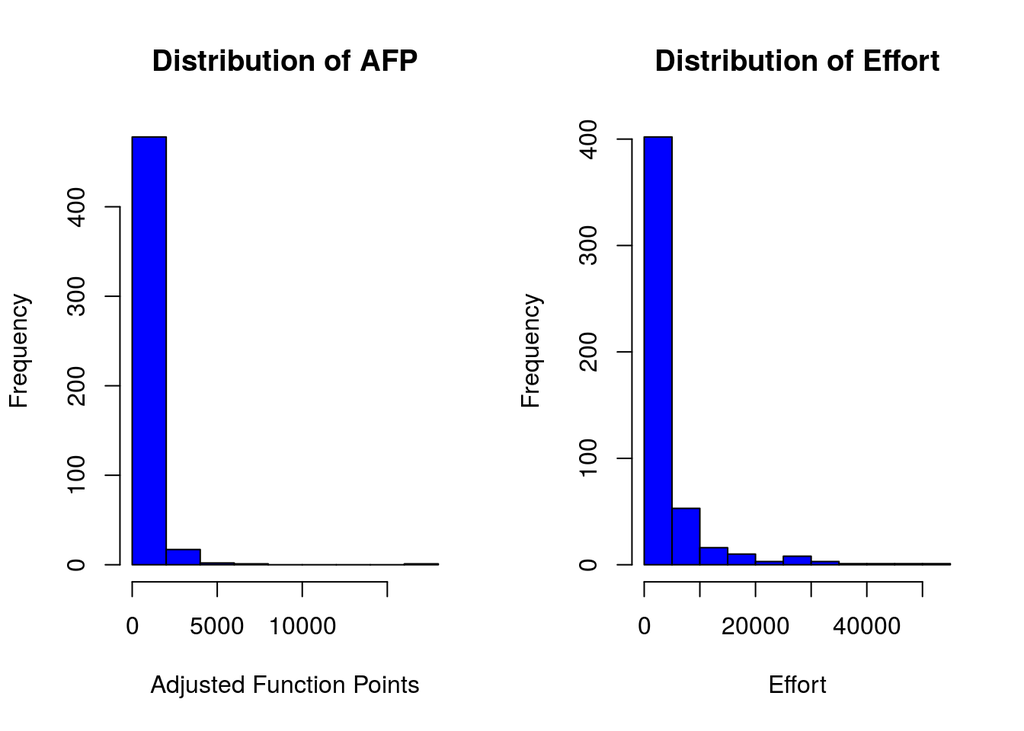

```r
par(mfrow=c(1,2))
hist(afpsize, col="blue", xlab="Adjusted Function Points", main="Distribution of AFP")
hist(effort_china, col="blue",xlab="Effort", main="Distribution of Effort")
```

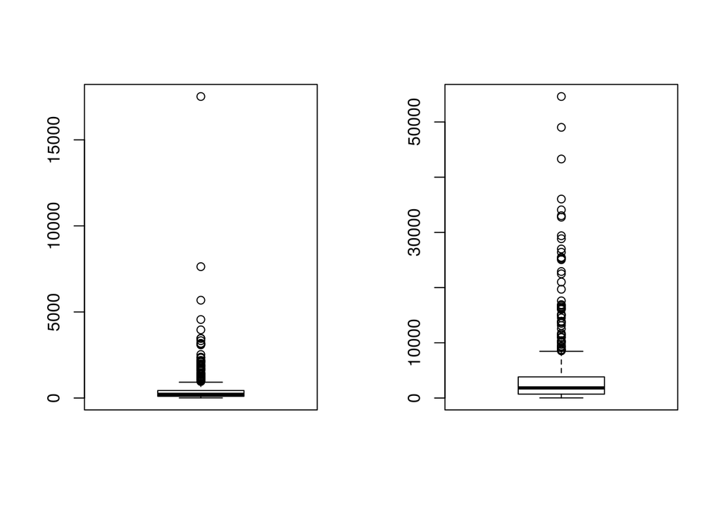

```r
boxplot(afpsize)
boxplot(effort_china)
```

## Normalization

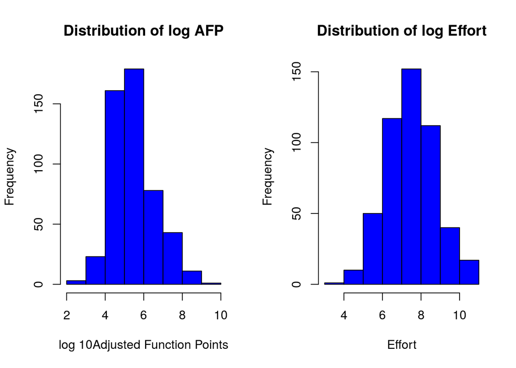

```r
par(mfrow=c(1,2))
logafp = log(afpsize)
hist(logafp, col="blue", xlab="log 10Adjusted Function Points", main="Distribution of log AFP")
logeffchina = log(effort_china)
hist(logeffchina, col="blue",xlab="Effort", main="Distribution of log Effort")
```

## Fitting a linear model to log-log (1)

- the predictive power equation is $y= e^{b_0 + b_1 log(x)}$, ignoring the bias corrections
- We are fitting the model to the whole dataset

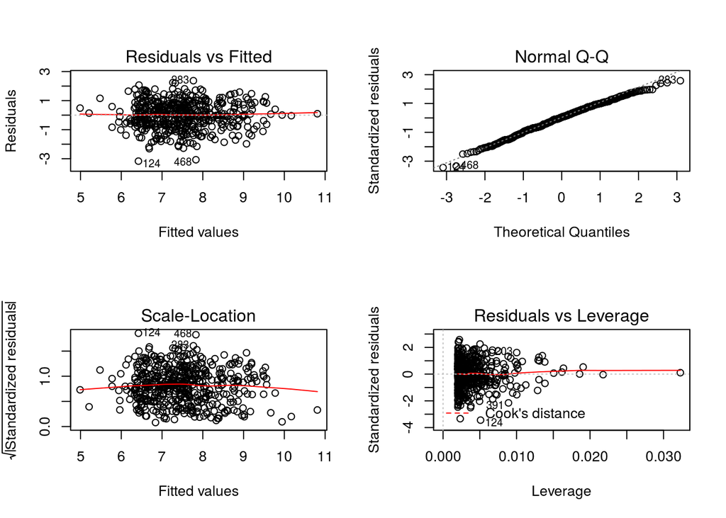

```r
linmodel <- lm(logeffchina ~ logafp)
par(mfrow=c(2,2))
plot(linmodel)
```

## Fitting a linear model splitting data into Training and Testing (2)

```r
chinaTrain <- read.arff("china3AttSelectedAFPTrain.arff")
afpsize <- chinaTrain$AFP
summary(afpsize)
```

```
##    Min. 1st Qu.  Median    Mean 3rd Qu.    Max.
##    25.0   112.8   227.5   504.0   477.2 17520.0
```

```r
effort_china <- chinaTrain$Effort
summary(effort_china)
```

```
##    Min. 1st Qu.  Median    Mean 3rd Qu.    Max.
##    80.0   771.5  2008.0  4286.0  4352.0 54620.0
```

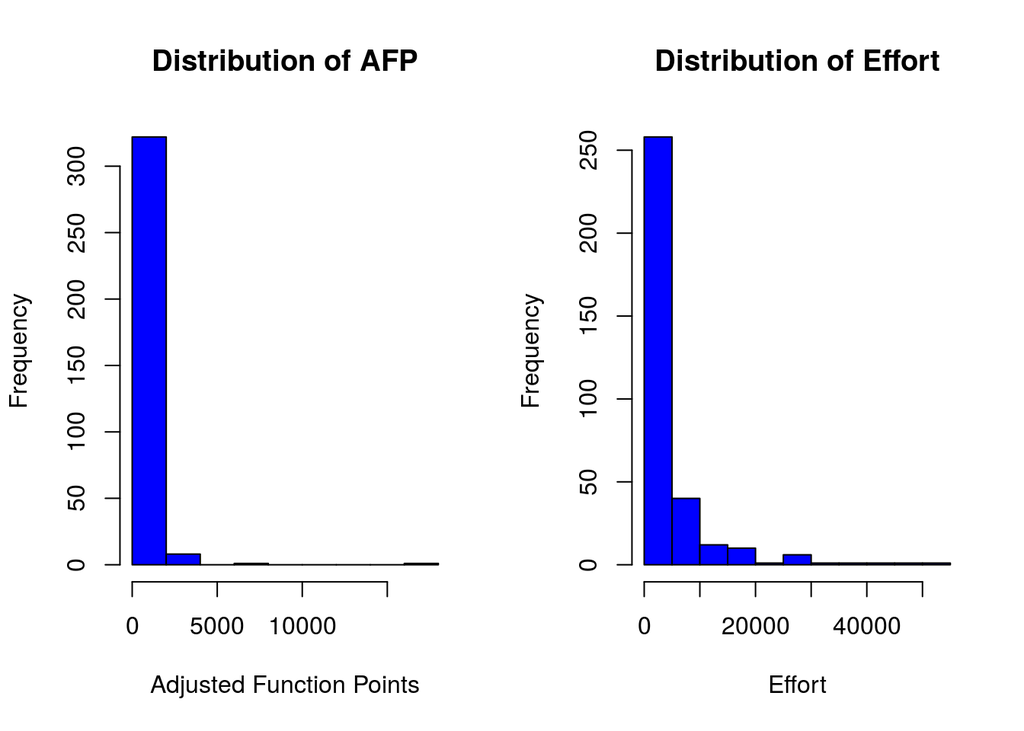

```r
par(mfrow=c(1,2))
hist(afpsize, col="blue", xlab="Adjusted Function Points", main="Distribution of AFP")
hist(effort_china, col="blue",xlab="Effort", main="Distribution of Effort")
```

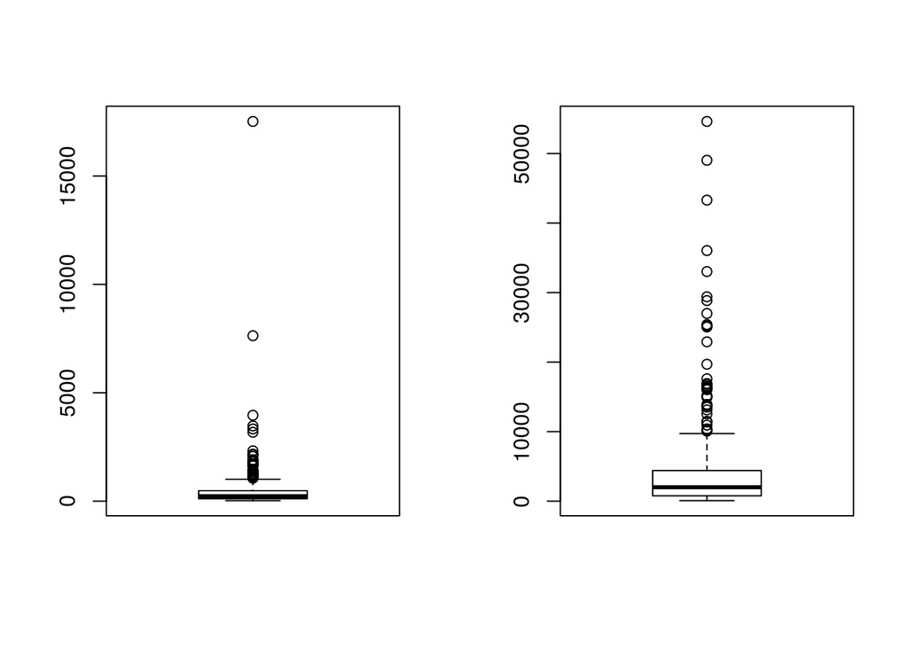

```r
boxplot(afpsize)
boxplot(effort_china)
```

## Normalization

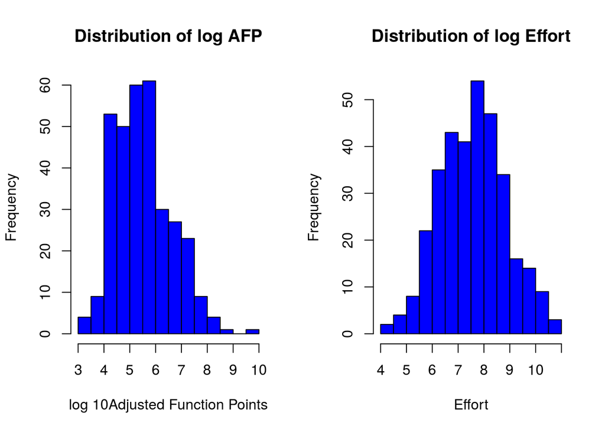

```r
par(mfrow=c(1,2))
logafp = log(afpsize)
hist(logafp, col="blue", xlab="log 10Adjusted Function Points", main="Distribution of log AFP")
logeffchina = log(effort_china)
hist(logeffchina, col="blue",xlab="Effort", main="Distribution of log Effort")
```

## Fitting a linear model to log-log (1)

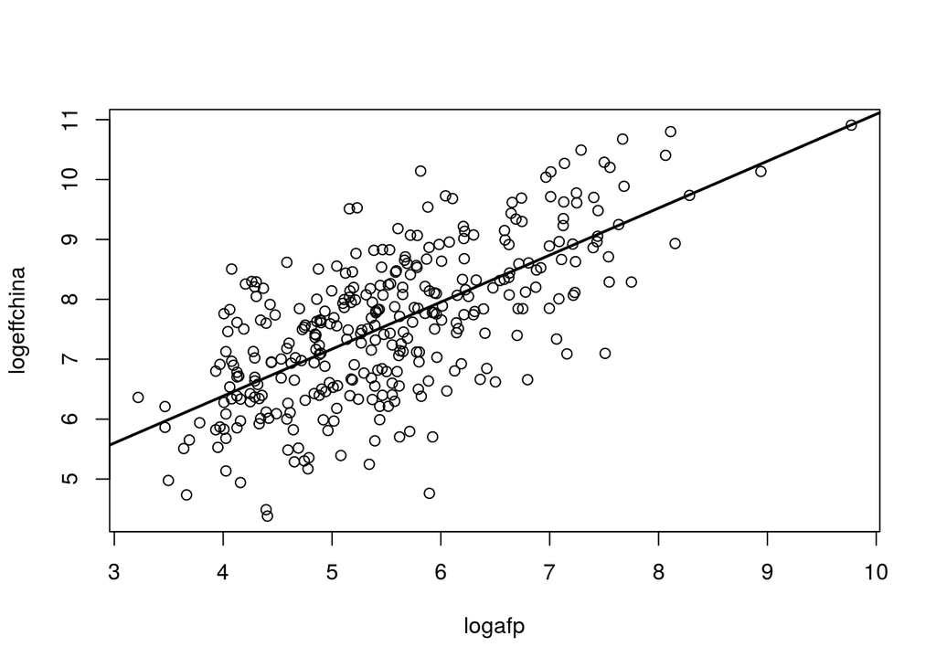

```r
linemodel <- lm(logeffchina ~ logafp)
plot(logafp,logeffchina)
abline(linemodel, lwd=2)
```

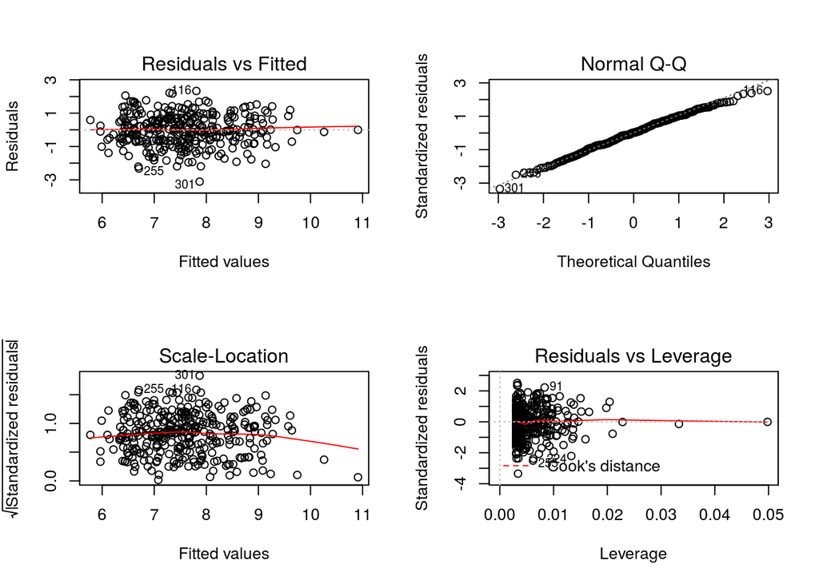

```r
par(mfrow=c(2,2))
plot(linemodel)
```

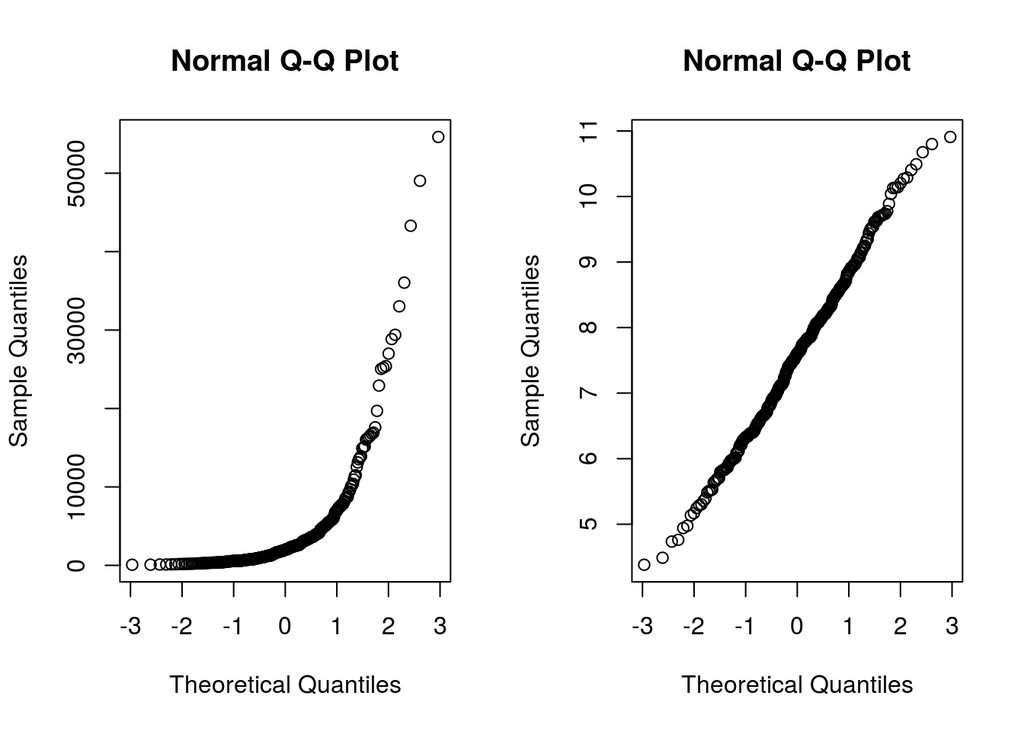

```r
par(mfrow=c(1,2))
qqnorm(effort_china)
qqnorm(logeffchina)
```

## Evaluation of the model in the Testing data (2)

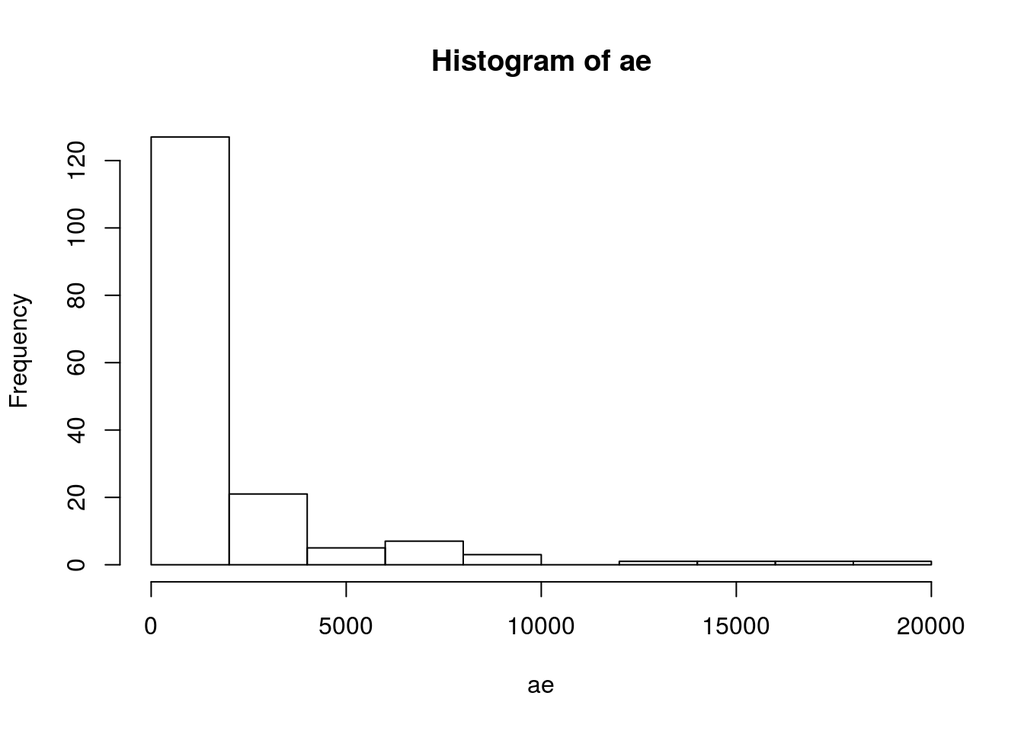

```r
gm_mean = function(x, na.rm=TRUE){
  exp(sum(log(x[x > 0]), na.rm=na.rm) / length(x))}

chinaTest <- read.arff("china3AttSelectedAFPTest.arff")
b0 <- linemodel$coefficients[1]
b1 <- linemodel$coefficients[2]
AFPTest <- chinaTest$AFP
actualEffort <- chinaTest$Effort
predEffort <- exp(b0+b1*log(AFPTest))

err <- actualEffort - predEffort  #error or residual
ae <- abs(err)
hist(ae)
```

```r
mar <- mean(ae)
mre <- ae/actualEffort
mmre <- mean(mre)
mdmre <- median(mre)
gmar <- gm_mean(ae)
mar
```

```
## [1] 1866.819
```

```r
mmre
```

```
## [1] 1.15106
```

```r
mdmre
```

```
## [1] 0.5510077
```

```r
gmar
```

```
## [1] 832.5504
```

## Standard Accuracy. MARP0. ChinaTest

- Computing $ MARP_0$ in the China Test data

```r
estimEffChinaTest <- predEffort  # This will be overwritten, no problem
numruns <- 9999
randguessruns <- rep(0, numruns)
for (i in 1:numruns) {
  for (j in 1:length(estimEffChinaTest)) {
    estimEffChinaTest[j] <- sample(actualEffort[-j],1)}#replacement with random guessingt
  randguessruns[i] <- mean(abs(estimEffChinaTest-actualEffort))
  }
marp0Chinatest <- mean(randguessruns)
marp0Chinatest
```

```
## [1] 3949.405
```

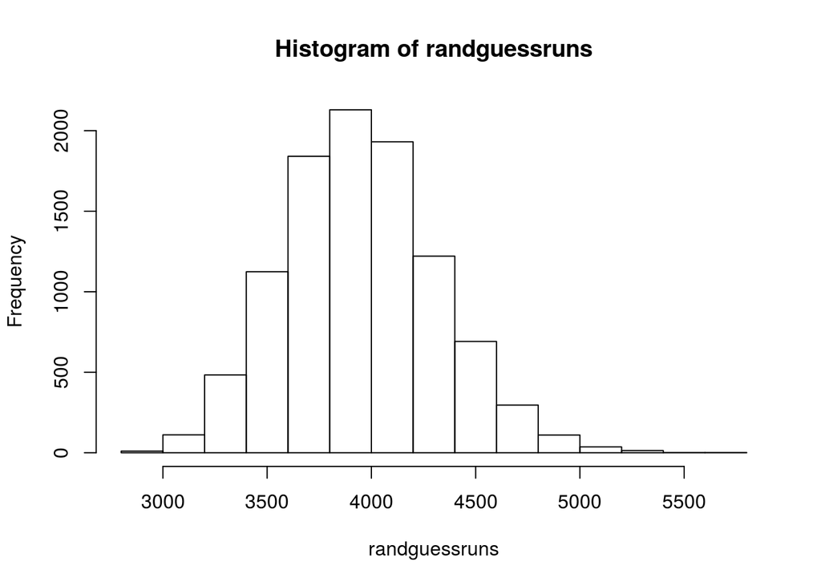

```r
hist(randguessruns)
```

```r
sa = (1- mar/marp0Chinatest)*100
sa
```

```
## [1] 52.73164
```

## Level of Prediction. LPred(l)

- Defined as the percentage of estimates that are within the level l% of the actual values
- Usually set at 25%

```r
level_pred <- 0.25
lowpred <- actualEffort*(1-level_pred)
uppred <-  actualEffort*(1+level_pred)
pred  <-  predEffort <= uppred & predEffort >= lowpred  #pred is a vector with logical values
Lpred <- sum(pred)/length(pred)
Lpred
```

```
## [1] 0.1856287
```

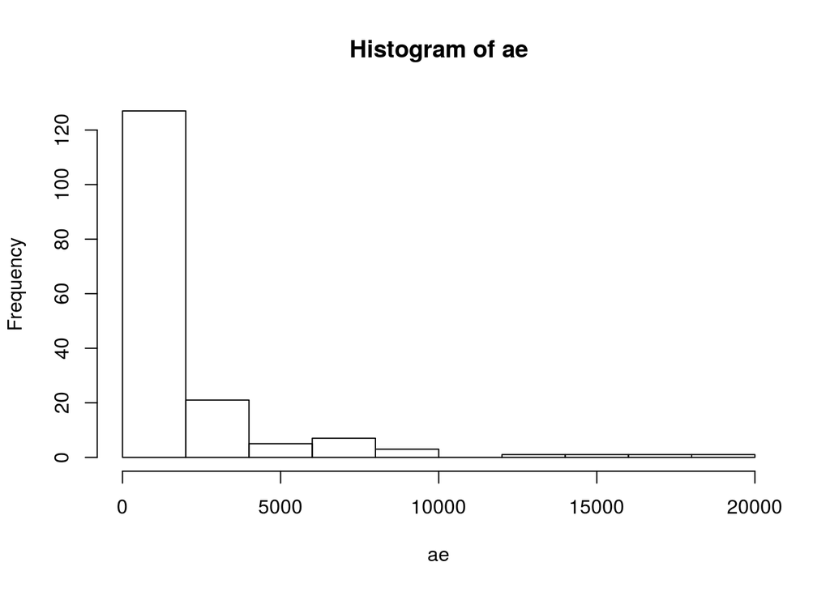

```r
hist(ae)
```

## Standard Accuracy. MARP0. Telecom1

- Computing $ MARP_0$
- For checking results you may use figure Atkinson in Shepperd&McDonnell

```r
path2files <- "~/DocProjects/PRESI2013/london2015"
setwd(path2files)
telecom1 <- read.table("Telecom1.csv", sep=",",header=TRUE, stringsAsFactors=FALSE, dec = ".") #read data
#par(mfrow=c(1,2))
#size <- telecom1[1]$size   not needed now
actualEffTelecom1 <- telecom1[2]$effort
estimEffTelecom1 <- telecom1[3]$EstTotal # this will be overwritten
numruns <- 9999
randguessruns <- rep(0, numruns)
for (i in 1:numruns) {
  for (j in 1:length(estimEffTelecom1)) {
    estimEffTelecom1[j] <- sample(actualEffTelecom1[-j],1)}#replacement with random guessingt
  randguessruns[i] <- mean(abs(estimEffTelecom1-actualEffTelecom1))
  }
marp0 <- mean(randguessruns)
marp0
```

```
## [1] 270.4395
```

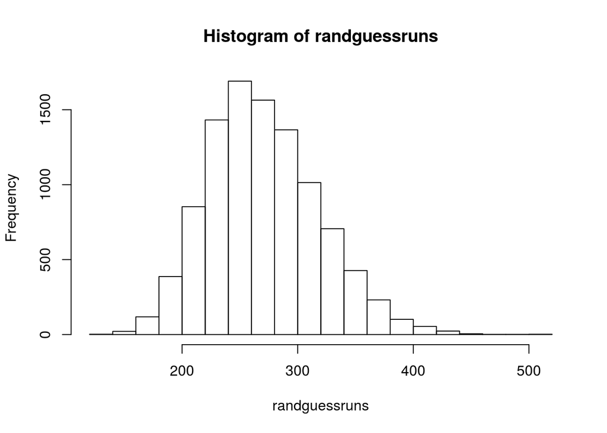

```r
hist(randguessruns)
```

### MARP0 in the Atkinson dataset

```r
act_effort <- c(670,912,218,595,267,344,229,190,869,109,289,616,557,416,578,438)
estim_effort <- rep(0, length(act_effort))
numruns <- 9999
randnaiveruns <- rep(0, numruns)
for (i in 1:numruns) {
  for (j in 1:length(act_effort)) {
    estim_effort[j] <- sample(act_effort[-j],1)}#replacement with random guessingt
  randnaiveruns[i] <- mean(abs(estim_effort-act_effort))
  }
marp0 <- mean(randnaiveruns)
marp0
```

```
## [1] 281.0221
```

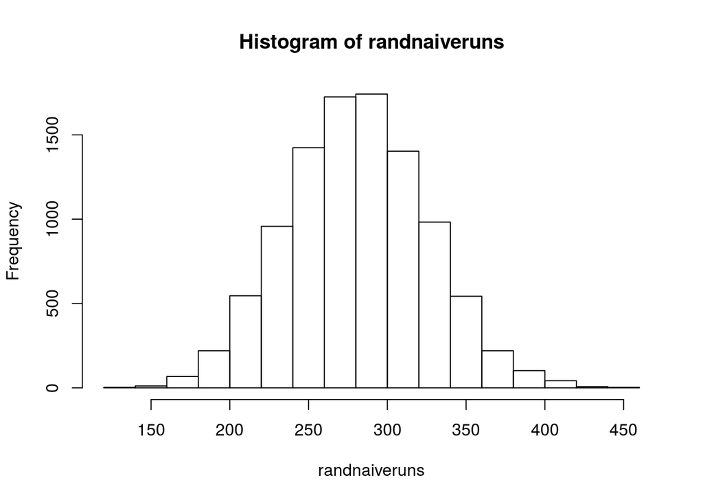

```r
hist(randnaiveruns)
```

## ISBSG dataset

```r
setwd("~/Dropbox/dhl/dataGeneration/DataSourcesFromWeka")
isbsgTrain8 <- read.arff("ISBSGv10_AttributesSelected_952Instances_8Att_Train_CLast.arff")
isbsgTest8 <- read.arff("ISBSGv10_AttributesSelected_952Instances_8Att_Test_CLast.arff")
```

## Galton Data works well

```r
library(UsingR); data(galton)
```

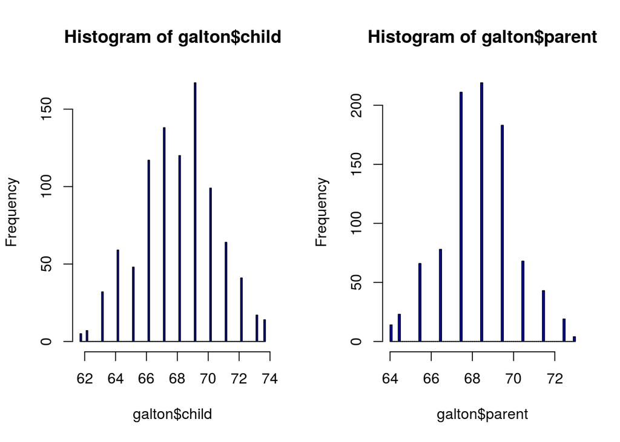

```r
par(mfrow=c(1,2))
hist(galton$child,col="blue",breaks=100)
hist(galton$parent,col="blue",breaks=100)
```

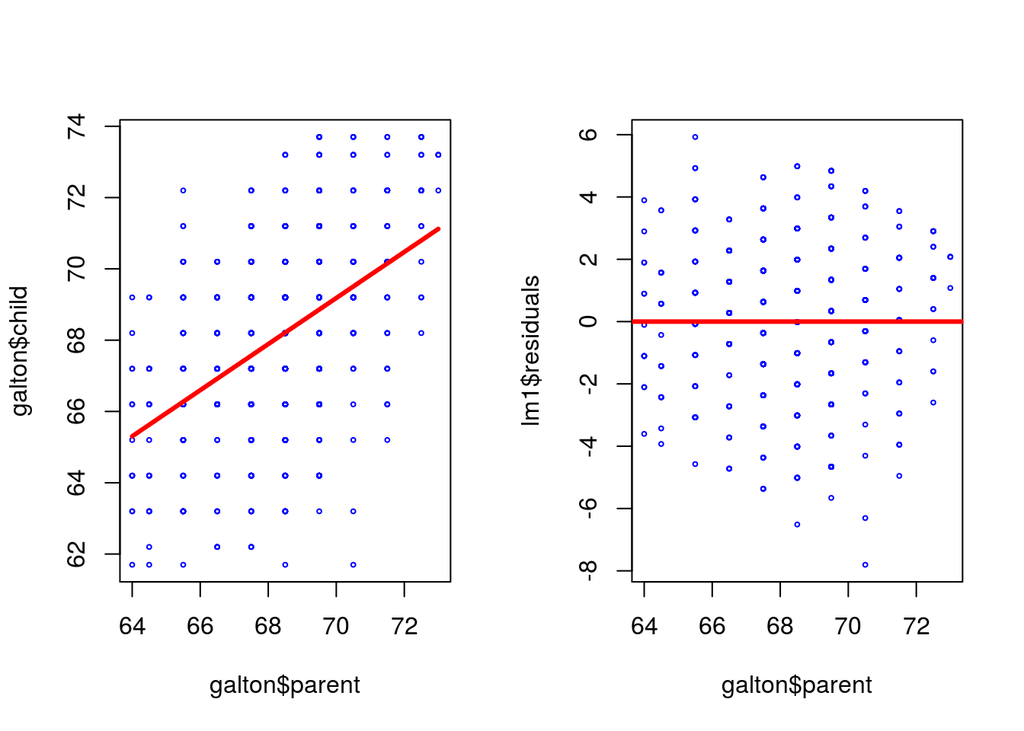

```r
plot(galton$parent,galton$child,pch=1,col="blue", cex=0.4)
lm1 <- lm(galton$child ~ galton$parent)
lines(galton$parent,lm1$fitted,col="red",lwd=3)
plot(galton$parent,lm1$residuals,col="blue",pch=1, cex=0.4)
abline(c(0,0),col="red",lwd=3)
```

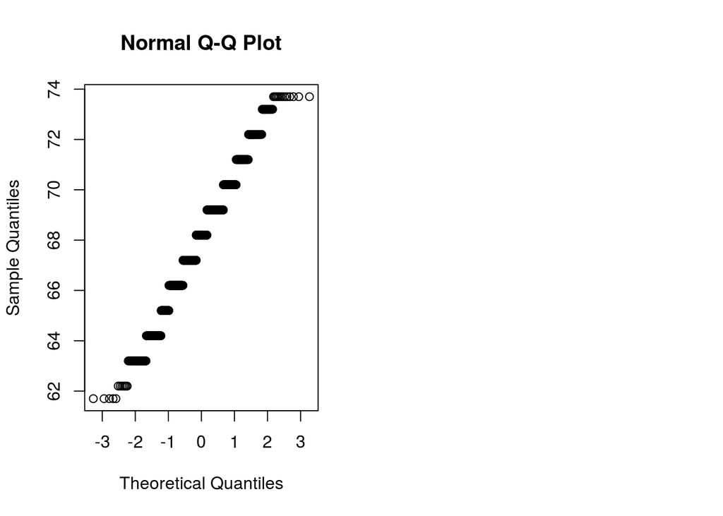

```r
qqnorm(galton$child)
```